# 297.101 Lecture JG2: Probability II

Author

Jonathan Godfrey a.j.godfrey@massey.ac.nz

[Watch the latest recording of this lecture](https://r-resources.massey.ac.nz/videos/SDS2.mp4)

## How can we tell a sports team is truly awesome?

Every competition has a winner, and often there is another team that gets the wooden spoon (the loser).

In most leagues, every team plays every other team a common number of times, sometimes once, sometimes both home and away games, and sometimes a hotch-potch of home and away games and neutral venues are used. OK, there are leagues where the draw doesn’t fit the common number for all pairs of teams.

Depending on the league, competition points are awarded to the teams for different reasons:

- Each game or match is won, lost or drawn in the English Premier League, worth 3, 0, or 1 competition point.
- Same goes for Super Rugby, albeit it 4, 0, and 2 points, but bonus competition points are on offer for a close loss or for scoring four tries.

It really does not matter how competition points are awarded.

If we randomly decided the outcome of all games, there would be a pattern of the way the teams are ordered at the end of the league. One team at the top and one at the bottom.

A truly awesome team would either:

- have a league standing that was so far above what random results would tell us is likely, or
- win the league over and over.

We might use historical data to help justify how we improve the random allocation of competition points, but in the end, we want to know if the outcome really is awesome.

## Basic rules of probability

A probability is described in three main ways. You might hear:

- I have a 1 in 3 chance of finishing this lecture on time.
- There is a 40% chance of rain today.
- The chance of having to wait for lunch is 0.2727

The use of a fraction or a percentage is useful for conversation, but the percentage is only useful for making calculations if you convert it to the decimal.

A probability is always between zero (absolutely no chance) and one (absolute certainty).

Important terms we use include:

- The language of probability often talks about **events** and **outcomes**.
- The **sample space** is the complete set of possible outcomes. The probability of something from the sample space occuring is one. We refer to the **totality of probability** being one.
- Either an event or its **complement** must happen. the probability of the **complement** of an event is *P(A<sup>c</sup>)=1-P(A)* where that little *c* might be replaced by a symbol looking like an apostrophe.
- If there are two events *A* and *B*, and they cannot both happen, they are said to be **mutually exclusive**. We can add their probabilities together if we are interested in knowing the probability of either occurring. *P(A* or *B)=P(A)+P(B)*.
- If *A* and *B* can both occur, we need to know if their probabilities are linked or **independent**.
- If (and only if) two events are independent, their joint probability (the probability of both occurring) is found by multiplying their probabilities together *P(A* and *B)=P(A)P(B)*.
- if *A* and *B* can both occur, then the probability of either occurring is *P(A* or *B)=P(A)+P(B)-P(A* and *B)*.

The rules for probability are very similar to rules you learned for sets. We refer to “unions” and intersections” from time to time instead of “or” and “and”. The symbols used for them are $∪$ and $∩$ respectively.

## How do we get probabilities?

Working out the chance of an outcome when we know the set of possible outcomes and ring-fence the ones of interest is pretty easy. Tossing coins and drawing cards is fairly boring so really only has value in providing simple examples in introductory stats classes.

Often though we must observe some real-world activity and learn about what is possible so that we can decide if a particular model is useful. Statisticians do this all the time.

A “model” is seldom perfect. Many imperfections have a trivial impact on the decision we make though.

### A Poisson process

A queue forms when a service facility cannot process every client at the instant they arrive to be served. In many queueing systems, the arrivals are random or are at least sufficiently random that we can’t prove otherwise.

We can’t just sit around waiting to observe thousands of customers, but we might use digital records of transactions to understand how many customers got processed each hour of each day, and we might even have to factor in some other reasons for fluctuations in the rate of people arriving at a check out.

We won’t do calculations using the Poisson distribution, but we can use it to generate random numbers that represent counts for a given expected rate. Let’s just imagine that a particular process truly does have a rate of $λ=5$. Let’s look at a random sample of size *n=2000*.

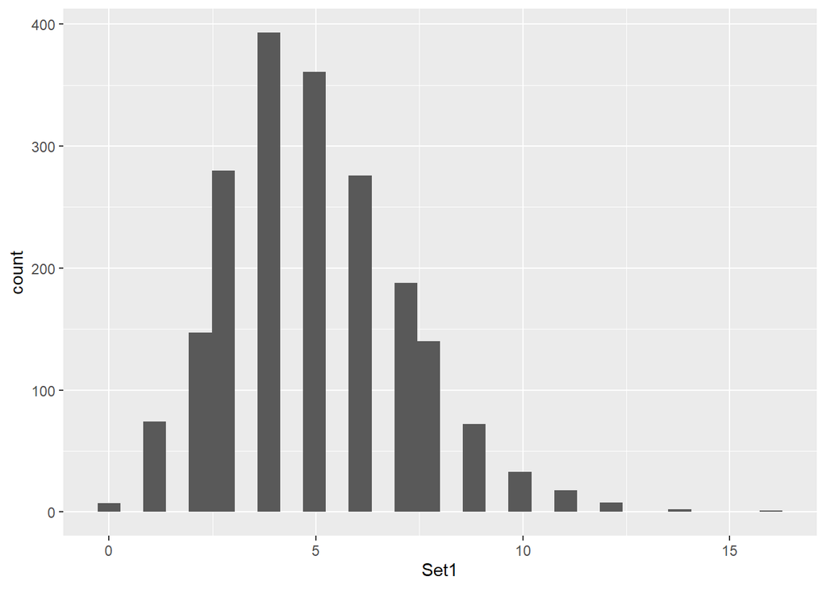

Histogram of 2000 random draws from Poisson with rate of 5

```r
set.seed(297101)  # for repeatability
Set1 = rpois(n = 2000, lambda = 5)
library(ggplot2)
ggplot(data.frame(Set1)) + aes(Set1) + geom_histogram()
```

But, what if the rate was not constant? What if it is 5 on average, perhaps being 4 half the time and 6 the other half?

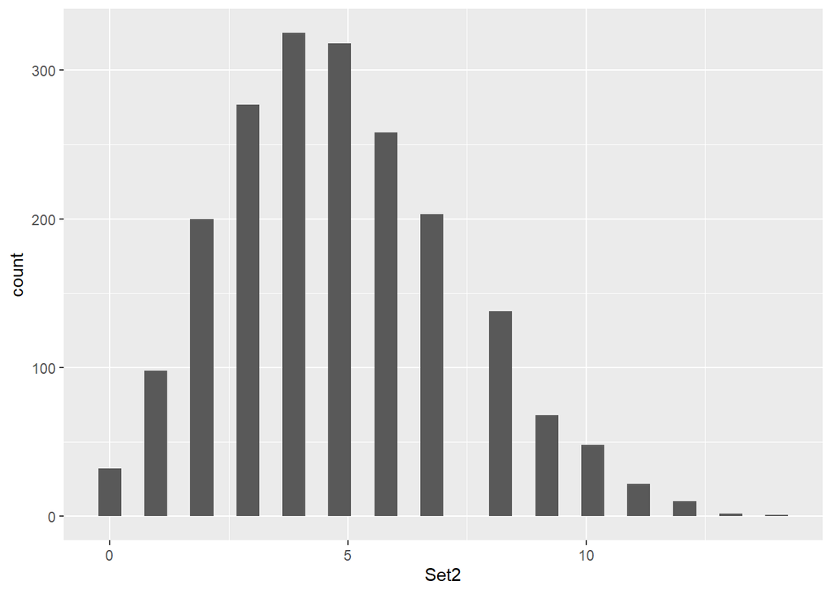

Histogram of combination of 1000 random draws from Poisson with rate of 4, and 1000 with rate 6

```r
Set2 = c(rpois(n = 1000, lambda = 4), rpois(n = 1000, lambda = 6))
library(ggplot2)  # not necessary here
ggplot(data.frame(Set1, Set2)) + aes(Set2) + geom_histogram()
```

One fact we know about all Poisson distributions, is that in theory, the mean is equal to the variance and both are equal to the expected rate. In practice though there will be slight departures from theory…

| Statistic | Set 1 | Set 2 |
| --- | --- | --- |
| Mean | 4.9965 | 4.893 |
| Variance | 4.8939347 | 5.8374697 |

While Set 1 has mean > variance, this is due to randomness. If I changed the random seed, I’d get different results, perhaps even having variance> mean for Set 1. Set 2 seems to have a much greater difference between the mean and variance.

### Imperfections?

Yes. The poisson model can calculate a probability of a million things being observed when we expected to see 5 on average. That sounds dopey, but while it is theoretically possible, it is practically impossible. Even the probability of observing anything over a hundred is `ppois(100, lambda=5, lower.tail=FALSE)` = $2.9647649×10−92$ which is a few numbers after 90 decimal places of zeroes!

The upshot is that even if my estimate is wrong by an order of magnitude, or even ten orders of magnitude, the outcome of observing one hundred things when I expect five is so ridiculously small that if it rreally did happen in real life, it would have been a situation my model was not equipped to deal with.

### Sensitivity analysis

How did I get my estimated average rate? This really matters, and considerably more than the presence of a feature in the model that amounts to being impossible.

I need to worry that my estimate is based on observed data, and perhaps the quality is questionable. My solution is to repeat my investigation using a range of parameter estimates that give me confidence that my decisions do not rely on my single estimate being perfect.

## Queueing scenarios

Making decisions that make sure there are enough facilities to meet demand or can handle the ebb and flow of demand is fascinating.

Why do some fast food outlets have multiple queues, one for each server, while others have one long line that feeds a group of servers?

Which is more efficient? How do we prove it?

The answer is to use probability models to determine what might happen, sometimes using theory (if it exists) or simulation (increasingly common).

BTW: One queue of customers waiting to be served by any of the *n* servers **is** better than having *n* queues. Average waiting time is shorter.

## Changes over time

Let’s imagine we count the number of speeding motorists at four locations each weekday over six weeks. N.B. This data is fictitious.

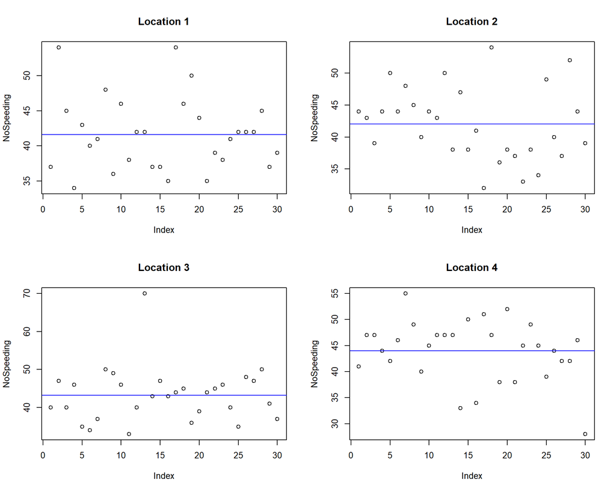

Count of speeding motorists at four locations

| Location | Daily Average | Maximum |
| --- | --- | --- |
| 1 | 41.633 | 54 |
| 2 | 42.033 | 54 |
| 3 | 43.233 | 70 |
| 4 | 44 | 55 |

So, if we were putting in a speed camera to help lower the number of speeding motorists, we would probably choose Location 4, right? … because it has the highest average and therefore total. (?)

Well yes, but would we be doing so for the right reasons?

I guess I could show you the code that generated the above scenario. The important thing to note would be that the four locations use exactly the same parameters. The results are just four random sets of numbers with the exact same inputs. I could extend this to as many locations as you like, but one of the locations will always end up being the worst according to any given criterion.

If a decision is made to concentrate on the “worst” location, the next time we saw data for that location, it would most likely show a reduction in the number of speeding motorists, even if there was no speed camera at all!

This happens all the time. OK, not with speed cameras, but situations when we worry about the best or worst performance, without really thinking of what really is good, great, or absolutely appalling.

All too often, interventions work because they get put in the places with the worst situations but the rate of bad things would have reduced anyway.

What we need to do is to collect data, prove that a phenomenon is persistent, and address that situation, even if the target does not have the worst average or the worst individual outcome.

[interactive chart not shown]